# LINDA

# LINDA Example

Below are provided examples which help the user to better understand the functioning of the LINDA R-package and the format of the LINDA inputs.

## Toy Example

Below are provided the steps of running a small Toy test study.

### 1. Loading of the required packages

R-packages needed to for the analysis.

```r
library(LINDA)
library(igraph)
library(XML)
library(aggregation)
```

### 2. Loading of a data-frame containing results from the alternative splicing/exon skipping analysis

```r
load(file = system.file("extdata", "as_data_toy.RData", package = "LINDA"))
print(as.input)
```

```
##     id   effect significance
## 1   T1  0.92970      0.04247
## 2   T2 -0.74497      0.71980
## 3   T3 -0.90946      0.04555
## 4   T4  0.90718      0.04041
## 5   T5  0.89081      0.53647
## 6   T6  0.12152      0.91656
## 7   T7 -0.98486      0.01095
## 8   T8  0.50813      0.16584
## 9   T9  0.99741      0.01207
## 10 T10 -0.64655      0.32724
## 11 T11  0.01542      0.57675
## 12 T12 -0.72558      0.92511
## 13 T13 -0.90826      0.00629
## 14 T14  0.23419      0.45952
```

### 3. Loading of a data frame of the prior knowledge network of protein-protein (PPI) and domain-domain (DDI) interactions

It is a data-frame object that should contain at lease 6 columns with the following ID’s: **gene_source:** gene names of the interaction sources in the PPI. **gene_target:** gene names of the interaction targets in the PPI. **pfam_source:** pfam domain ID’s of the interaction sources in the DDI. **pfam_target:** pfam domain ID’s of the interaction targets in the DDI. **exon_source:** transcript ID’s mapping to the pfam and protein of the source interactions. In case multiple transcript ID’s map to a domain of a specific protein, then the multiple transcripts are separated by an underscore symbol. **exon_target:** transcript ID’s mapping to the pfam and protein of the target interactions. In case multiple transcript ID’s map to a domain of a specific protein, then the multiple transcripts are separated by an underscore symbol.

```r
load(file = system.file("extdata", "bg_toy.RData", package = "LINDA"))
print(bg)
```

```
##    exon_source exon_target pfam_source pfam_target gene_source gene_target
## 1           T3          T8          D3          D8          P1          P4
## 2           T3          T5          D3          D5          P1          P3
## 3           T2          T5          D2          D5          P1          P3
## 4           T4          T6          D4          D6          P2          P3
## 6           T4         T10          D4         D10          P2          P5
## 8           T5          T8          D5          D8          P3          P4
## 9           T7          T8          D7          D8          P3          P4
## 13          T7         T12          D7         D12          P3          M2
## 14          T6         T14          D6         D14          P3          M3
## 15          T9         T11          D9         D11          P4          M1
## 16          T9         T12          D9         D12          P4          M2
## 21         T10         T13         D10         D13          P5          M2
```

In **Figure 2** is provided a depiction of the Toy case background network.

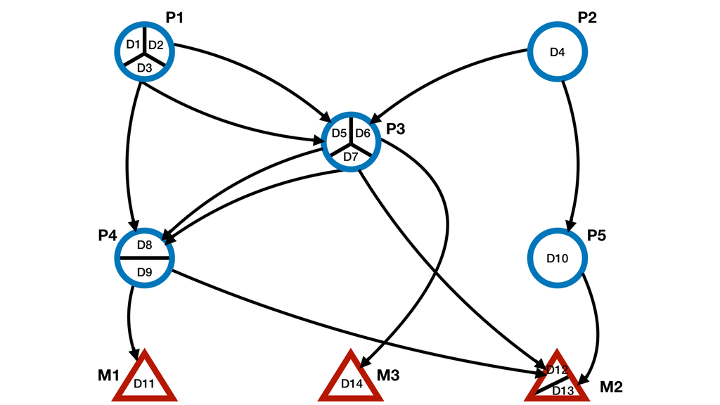

**Figure 2:** Background Network depiction of the Toy case study

### 4. Transcription Factor Activities

It is a data-frame object that should consist of two columns containing the estimated transcription factor activities (TF). The data-frame should have columns ID’s as `c('id', 'nes')`, indicating to the TF ID’s and the corresponding inferred enrichment score.

```r
load(file = system.file("extdata", "tf_act_toy.RData", package = "LINDA"))
print(input.scores)
```

```
##   id nes
## 1 M1   1
## 2 M2  -1
## 3 M3   0
```

### 5. LINDA Analysis

Once the inputs are available, the users can the proceed with the LINDA network analysis. The regulatory networks can be inferred by executing the `runLINDA()` function. Details about how to use this function can be obtained by using the `?runLINDA` command.

Below is shown an example of how we can use the `runLINDA()` function given the inputs from the toy example as well as making use of the default CPLEX optimization parameters.

LINDA can use alternative-splicing information in two ways through the `constraints_mode` argument. The default is `constraints_mode = "hard"`, which keeps the original AS-constraint formulation and forces significantly affected reactions to zero according to `pValThresh` and `splice_effect_sign`. Alternatively, `constraints_mode = "soft"` keeps AS-affected reactions feasible but penalizes them in the objective function. The default `splice_effect_sign` is now `"negative"`, while `"positive"` and `"both"` remain available.

```r
res <- runLINDA(input.scores = input.scores, as.input = as.input,
                background.network = bg, solverPath = "~/Downloads/cplex",
                input.node = NULL, constraints_mode = "hard", pValThresh = 0.05,
                splice_effect_sign = "negative", top = 2, lambda1 = 10,
                lambda2 = 0.001, mipgap = 0.001, relgap = 0.001)
```

```
## [1] "Processing the Background Network.."
## [1] "Writing the objective function and constraints.\n        This might take a bit of time.."
```

```r
print(res)
```

```
## $separate_interactions
## $separate_interactions[[1]]
##      [,1]           [,2] [,3] [,4]
## [1,] "P1"           "1"  "P3" "D2=D5"
## [2,] "P3"           "1"  "P4" "D5=D8"
## [3,] "P4"           "1"  "M1" "D9=D11"
## [4,] "P4"           "1"  "M2" "D9=D12"
## [5,] "Perturbation" "1"  "P1" "Perturbation=D2"
##
## $separate_interactions[[2]]
##      [,1]           [,2] [,3] [,4]
## [1,] "P1"           "1"  "P3" "D2=D5"
## [2,] "P2"           "1"  "P3" "D4=D6"
## [3,] "P3"           "1"  "P4" "D5=D8"
## [4,] "P4"           "1"  "M1" "D9=D11"
## [5,] "P4"           "1"  "M2" "D9=D12"
## [6,] "Perturbation" "1"  "P1" "Perturbation=D2"
## [7,] "Perturbation" "1"  "P2" "Perturbation=D4"
##
## $separate_interactions[[3]]
##      [,1]           [,2] [,3] [,4]
## [1,] "P2"           "1"  "P3" "D4=D6"
## [2,] "P3"           "1"  "P4" "D5=D8"
## [3,] "P4"           "1"  "M1" "D9=D11"
## [4,] "P4"           "1"  "M2" "D9=D12"
## [5,] "Perturbation" "1"  "P2" "Perturbation=D4"
##
##
## $combined_interactions
##      source         weight target reaction
## [1,] "P1"           "2"    "P3"   "D2=D5"
## [2,] "P3"           "3"    "P4"   "D5=D8"
## [3,] "P4"           "3"    "M1"   "D9=D11"
## [4,] "P4"           "3"    "M2"   "D9=D12"
## [5,] "Perturbation" "2"    "P1"   "Perturbation=D2"
## [6,] "P2"           "2"    "P3"   "D4=D6"
## [7,] "Perturbation" "2"    "P2"   "Perturbation=D4"
```

The output of the analysis is a list object containing the separate LINDA analysis optimal networks (`res$separate_interactions`) as well as a matrix containing all the integrated interactions obtained from each of the separate solutions (`res$combined_interactions`). The integrated networks contains information about the source and target of each inferred interaction (`source` and `target` columns) associated with a weight value (`weight` column, indicating how frequently each separate interaction appears across the multiple solutions) as well as a list of the potential interacting structural domains identifiable through the *Pfam* ID’s (`reaction` column).

If the user wishes to better check the AS effects, they can additionally perform a network analysis without considering the AS effects. In this case LINDA will additionally infer potential mechanisms involving those domains which did not appear to be functional in the previous analysis. For running the splice-unaware form of LINDA, the users can simply set `as.input = NULL` and perform the analysis as follows:

```r
res <- runLINDA(input.scores = input.scores, as.input = NULL,
                background.network = bg, solverPath = "~/Downloads/cplex",
                input.node = NULL, constraints_mode = "hard", pValThresh = 0.05,
                splice_effect_sign = "negative", top = 2, lambda1 = 10,
                lambda2 = 0.001, mipgap = 0.001, relgap = 0.001)
```

```
## [1] "Processing the Background Network.."
## [1] "Writing the objective function and constraints.\n        This might take a bit of time.."
```

```r
print(res$combined_interactions)
```

```
##       source         weight target reaction
##  [1,] "P1"           "39"   "P4"   "D3=D8"
##  [2,] "P4"           "100"  "M1"   "D9=D11"
##  [3,] "P4"           "50"   "M2"   "D9=D12"
##  [4,] "Perturbation" "90"   "P1"   "Perturbation=D2; Perturbation=D3"
##  [5,] "P2"           "12"   "P3"   "D4=D6"
##  [6,] "P3"           "78"   "P4"   "D7=D8; D5=D8"
##  [7,] "Perturbation" "18"   "P2"   "Perturbation=D4"
##  [8,] "P1"           "82"   "P3"   "D3=D5; D2=D5"
##  [9,] "P2"           "8"    "P5"   "D4=D10"
## [10,] "P5"           "8"    "M2"   "D10=D13"
## [11,] "P3"           "58"   "M2"   "D7=D12"
```

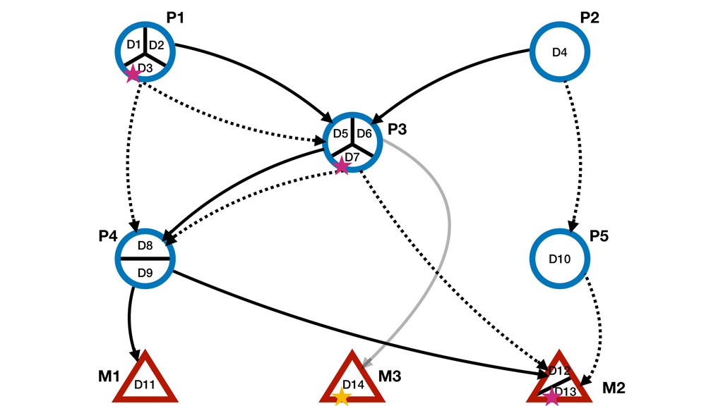